# Sparse spatio-temporal Leroux-AR in STAN

There is a rich literature on *Gaussian Markov Random Fields* and *Conditional Auto Regressive* (CAR) priors that suite the modeling of dependent random effects over a network. They have seen wide applicability in the disease mapping context, and much interest has been recently devoted to their extension in the space-time setting. We here consider the space-time extension of the Leroux model originally proposed by (Rushworth, Lee, and Mitchell 2014) and its sparse and efficient implementation in STAN.

## The Leroux model

Let $\phi_{s}, \;s=1,\dots,l$ be the set of Gaussian spatial random effects over a discrete domain $\mathcal{S}=\left\lbrace \boldsymbol{s}_1, \dots, \boldsymbol{s}_l\right\rbrace$. Let $\boldsymbol{W}$ be a $l\times l$ adjacency matrix for the locations in $\mathcal{S}$, whose elements $w_{ij}$ are $>0$ if and only if $i\neq j$ and $i\sim j$ (location $\boldsymbol{s}_i$ is a neighbor of location $\boldsymbol{s}_j$), and $0$ otherwise. Notice that each location is not a neighbor to itself.

The Leroux model extends the typical ICAR specification through a convex combination of its precision matrix with that of a Multivariate Gaussian with independent components. This is achieved through the inclusion of a coefficient $\alpha\in (0, 1)$. It regulates the extent of the spatial dependence and induces the following proper joint prior:
$$\boldsymbol{\phi} \sim
\mathcal{N}_l\left(\boldsymbol{0},\;
\sigma^2\cdot\boldsymbol{Q}(\alpha,\,\boldsymbol{W})^{-1}\right),$$
where $\sigma^2>0$ and
$$\boldsymbol{Q}(\alpha,\,\boldsymbol{W})=\left(
\alpha\cdot(\boldsymbol{D}-\boldsymbol{W}) +
(1-\alpha)\boldsymbol{I}_l\right).$$

### Sparse implementation of the Leroux model

We implement the model in `R` (R Core Team 2019) via `STAN` (Carpenter et al. 2017). Implementation of this model require computing the determinant and quadratic form of the $l\times l$ matrix $\boldsymbol{Q}(\alpha, \boldsymbol{W})$. This can become computationally expensive in many modrn applications, that often deal with $l$ fairly large (at least $l>100$).

This bottleneck is typical of many others CAR specification (proper CAR, etc.) and it requires the adoption of ad-hoc strategies to estimate the model in a reasonable amount of time (Jin, Carlin, and Banerjee 2005). We can do so exploiting the inherent sparsity pattern in $\boldsymbol{Q}(\alpha, \boldsymbol{W})$, deriving from the sparsity in $\boldsymbol{W}$.

- Only few entries of $\boldsymbol{Q}(\alpha, \boldsymbol{W})$ are different from zero and we can significantly speed up the evaluation by computing only the non-zero entries
- We can draw exploit a basic matrix manipulation to derive an efficient computational strategy to evaluate the determinant of $\boldsymbol{Q}(\alpha, \boldsymbol{W})$. Indeed, we have that
  $$\boldsymbol{Q}(\alpha,\boldsymbol{W}) =
  \left(\boldsymbol{I}_l-\alpha\left(\boldsymbol{W}+\boldsymbol{I}_l-\boldsymbol{D}\right)\right)$$
  and, by basic linear algebra properties:
  $$|\boldsymbol{Q}(\alpha,\boldsymbol{W})|\propto
  \prod_{i=1}^l(1-\alpha\lambda_i),$$
  where $\lambda_i=1,\dots, l$ are the eigenvalues of $\left(\boldsymbol{W}+\boldsymbol{I}_l-\boldsymbol{D}\right)$. These do not vary from iteration to iteration and can be computed only once at the beginning.

### Example

We will use the following information:

- `observed`: number of recorded lip cancer cases $y_s, s=1,\dots,l$.
- `expected`: expected number of lip cancer cases according to the indirect standardisation using Scotland-wide disease rates $o_s, s=1,\dots,l$.
- `pcaff`: the percentage of the workforce employed in agriculture, fishing and forestry. We use it under the `log1p` transform and scaling to get $x_s, s=1,\dots,l$.

We consider a typical Poisson regression with spatial random effects:
$$y_s \sim Poi(\lambda_s),\quad
\log(\lambda_s)= \log(o_s) + \beta_0 + \beta_1\cdot x_s +
\phi_s$$

where $\phi_s$ is modeled according to the Leroux model.

The data can be loaded from the `CARBayes` and `CARBayesData` packages. We will make use also of the other following packages.

We load the data and combine them.

```r
# Loading raw data
data("lipdata")
data("lipshp")
data("lipdbf")

# Combining data
lipdbf$dbf <- lipdbf$dbf[ ,c(2,1)]
data.combined <- combine.data.shapefile(data=lipdata, shp=lipshp, dbf=lipdbf) %>% st_as_sf()
```

We derive the neighboring structure.

```r
# Neighboring matrix
Wnb <- poly2nb(data.combined)
W <- nb2mat(Wnb, zero.policy = TRUE, style = "B")
```

Let us visualize the log-relative risks and the log-pcaff covariate.

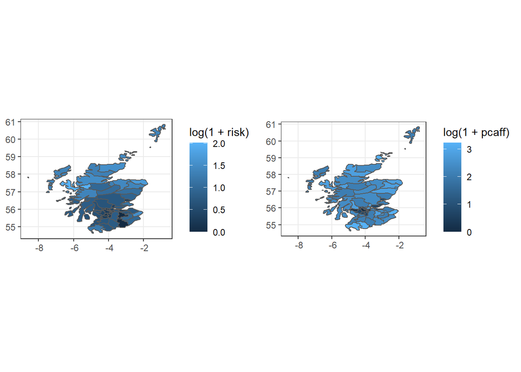

We will fit to those data the Leroux and its sparse version, available in the folder as *Leroux.stan* and *Leroux_Sparse.stan*. The core of the sparse version is the following likelihood function and the corresponding determinant computation. This implementation starts from the sparse version of the *proper CAR* by (Joseph 2016). The eigen-values $\lambda_i$ and the sparse versions `W_sparse` and `ID_sparse` of $\boldsymbol{W}$ and $(\boldsymbol{I}-\boldsymbol{D})$ can be computed in advance and given in input or evaluated in the transformed data section.

```r
functions {
  real sparse_Leroux_lpdf(vector phi, real alpha, int[,] W_sparse, vector W_weight,
                          vector ID_sparse, real sumlogdet, int n, int W_n) {
      row_vector[n] phit_ID; // phi' * D
      row_vector[n] phit_W; // phi' * W

      phit_ID = (phi .* ID_sparse)';
      phit_W = rep_row_vector(0, n);
      for (i in 1:W_n) {
        phit_W[W_sparse[i, 1]] = phit_W[W_sparse[i, 1]] + W_weight[i]*phi[W_sparse[i, 2]];
        phit_W[W_sparse[i, 2]] = phit_W[W_sparse[i, 2]] + W_weight[i]*phi[W_sparse[i, 1]];
      }

      return 0.5 * (sumlogdet
                    - (phi' * phi - alpha * (phit_ID * phi + phit_W * phi)));
  }
}

data {  ...  }

parameters {  ...  }


model {
        ...

        // CAR priors
        {
          vector[N] ldet_terms;
          real sumlogdet;

          // CAR determinant
          for (i in 1:N){
            ldet_terms[i] = log1m(alpha * lambda[i]);
          }
          sumlogdet = sum(ldet_terms);
          // CAR prior
          phi ~ sparse_Leroux(alpha, W_sparse, W_weight, ID_sparse, sumlogdet, N, W_n);
        }

        ...

    }
```

In my implementation the sparse representations are computed in the `transformed data` section of the STAN code. We then prepare the data for input in STAN.

```r
# Data
N <- nrow(data.combined)
O <- data.combined$observed
E <- data.combined$expected
X <- model.matrix(~.,
                  data=lipdata %>% dplyr::select(pcaff) %>%
                    mutate(across(everything(), function(x) scale(log1p(x)))))

# Data for the Leroux
lipList <- list(N = N,
                Y = O,
                lOff = log(E),
                W = W,
                k = ncol(X),
                X = X)

# Data for the Sparse Leroux
lipListSp <- list(N = N,
                Y = O,
                lOff = log(E),
                W = W,
                W_n = sum(W[upper.tri(W)]>0),
                k = ncol(X),
                X = X)
```

We can then setup the STAN options and compile the STAN code.

```r
# Setting up STAN options
rstan_options(auto_write = TRUE)
n_iter <- 3000
n_chains <- 1
n_cores <- max(n_chains, parallel::detectCores()-1)

# Stan compilation
stan_CodeLer <- stan_model("Leroux.stan")
stan_CodeLerSp <- stan_model("Leroux_Sparse.stan")
```

Finally, we fit the two versions of the model on the data and compare the execution times.

```r
fit_Ler <- sampling(stan_CodeLer, data = lipList,
                    chains = n_chains, iter = n_iter,
                    cores = n_cores,
                    pars = c("lm", "P"), include=F, seed=111)
fit_LerSp <- sampling(stan_CodeLerSp, data = lipListSp,
                      chains = n_chains, iter = n_iter,
                      cores = n_cores,
                      pars = c("lm"), include=F, seed=111)
```

The second version provided the results in way less time ($\approx 1/5$), yielding almost identical inferences as shown here below.

```r
betas <- paste0("beta[", 1:(ncol(X)), "]")
cars <- c("alpha", "sigmac")

# Check divergences
np_Ler <- bayesplot::nuts_params(fit_Ler)
np_LerSp <- bayesplot::nuts_params(fit_LerSp)

# The summary
sumLer <- summary(fit_Ler, pars=c(betas, cars))
sumLerSp <- summary(fit_LerSp, pars=c(betas, cars))
sumLer$summary
```

```
##               mean     se_mean         sd         2.5%        25%        50%
## beta[1] 0.09530696 0.001060840 0.05298303 -0.007236078 0.06094519 0.09557272
## beta[2] 0.30344290 0.003908092 0.09741796  0.113041659 0.23651718 0.30055624
## alpha   0.80894289 0.004316776 0.14345344  0.455623904 0.73392167 0.83878359
## sigmac  0.73136963 0.005043477 0.11630023  0.536966086 0.64520088 0.72106682
##               75%     97.5%     n_eff      Rhat
## beta[1] 0.1310216 0.1999381 2494.4427 0.9993332
## beta[2] 0.3690426 0.5011618  621.3675 0.9999277
## alpha   0.9213116 0.9881245 1104.3401 1.0004918
## sigmac  0.8030810 0.9953625  531.7422 0.9996481
```

```r
sumLerSp$summary
```

```
##               mean     se_mean         sd        2.5%        25%        50%
## beta[1] 0.09559722 0.001245541 0.05143149 -0.00430493 0.06001818 0.09734034
## beta[2] 0.30883579 0.003672934 0.09694188  0.10672862 0.24567725 0.31086608
## alpha   0.80381976 0.004590962 0.14272265  0.43924097 0.72384462 0.83680963
## sigmac  0.73775894 0.005864718 0.12212468  0.53115625 0.65033980 0.72708606
##               75%     97.5%     n_eff      Rhat
## beta[1] 0.1317480 0.1938428 1705.0686 0.9993339
## beta[2] 0.3729942 0.4948299  696.6210 1.0002986
## alpha   0.9121018 0.9846082  966.4477 0.9994187
## sigmac  0.8153081 0.9952680  433.6232 1.0006684
```

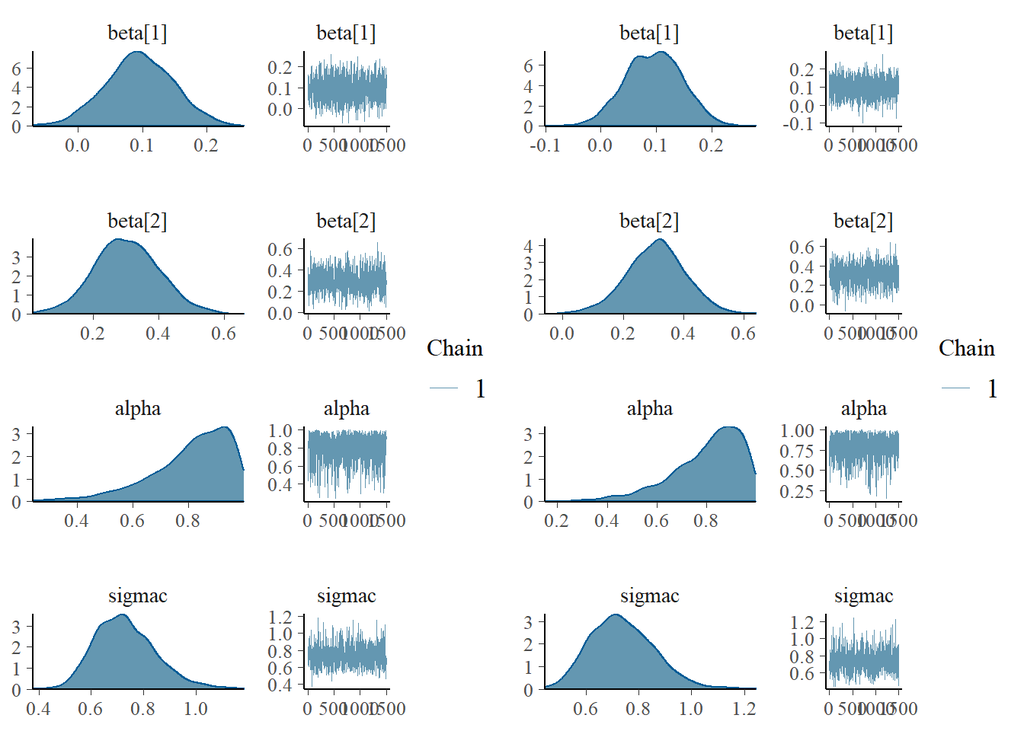

```r
# Extracting pars
pPars <- rstan::extract(fit_Ler, permuted = FALSE, pars=c(betas, cars))
pParsSp <- rstan::extract(fit_LerSp, permuted = FALSE, pars=c(betas, cars))


p1 <- bayesplot::mcmc_combo(pPars,
                      np=np_Ler)
p2 <- bayesplot::mcmc_combo(pParsSp,
                      np=np_LerSp)

gridExtra::grid.arrange(p1, p2, nrow=1)
```

## The Leroux-AR model

The Leroux-AR space-time extension connects $T$ temporal slices of spatial random effects $\boldsymbol{\Phi}=\left[\boldsymbol{\phi_1},\dots,\boldsymbol{\phi_T}\right]$ through a first-order auto-regressive structure:

$$\boldsymbol{\phi}_1\sim \mathcal{N}_l
\left( \boldsymbol{0},\; \sigma^2 \cdot \boldsymbol{Q}\left(\alpha,
\boldsymbol{W}\right)^{-1}\right)$$
$$\boldsymbol{\phi}_t\,|\,\boldsymbol{\phi}_{t-1},\dots,\boldsymbol{\phi}_1\sim
\mathcal{N}_l\left( \rho\cdot\boldsymbol{\phi}_{t-1},\,
\sigma^2\cdot\boldsymbol{Q}\left(\alpha,
\boldsymbol{W}\right)^{-1}\right),\; t=2,\dots,T.$$

The parameter $0<\rho<1$ is the temporal auto-regressive coefficient, controlling for temporal dependence. We denote with $\boldsymbol{\theta}=(\alpha, \rho, \sigma)$ the vector of coefficients on which the Leroux-AR specification depends on.

### The non-centered parametrization

STAN benefits from non-centered parametrization of parameters and random effects. It improves the geometry of the posterior and facilitates its exploration. Therefore, when coding the Leroux-AR in STAN it can be extremely beneficial sampling independent spatial vectors in the `model block` and then induce the temporal dependence across the spatial vectors at different times in the `transformed parameters block`. In practice, we must create some auxiliary vectors $\boldsymbol{\phi}_t^*$ such that:

$$\boldsymbol{\phi}^*_t\, \sim \,
\mathcal{N}\left(\boldsymbol{0}\,,\,\boldsymbol{Q}\left(\alpha,
\boldsymbol{W}\right)^{-1}\right), \quad t=1,\dots,T$$

and then evaluate $\boldsymbol{\phi}_1\, = \, \boldsymbol{\phi}_1^{*}$ and:

$$\quad \boldsymbol{\phi}_t\, = \,
\rho\cdot\boldsymbol{\phi}_{t-1} + \boldsymbol{\phi}_t^{*}, \quad
t=2,\dots, T$$

### Example

We will use the following information:

- `Y`: number of weekly cases in each district $y_{st},\; s=1,\dots,l,\; t=1,\dots,T$.
- `popn`: population size of each district $p_s,\; s=1,\dots,l$.
- `popden`: population density of each district. We apply a log-transform and scale the variable to get $x_{st},\; s=1,\dots,l,\; t=1,\dots,T$.

We load the data.

```r
# London cases
load("LondonData.RData")

# London map
load("LondonMap.RData")
```

We can compute the neighboring structure as follows. The snap allows to connect region that would be separated by thin sections of the Thames river.

```r
# Computing neighbors
W0 <- sfdep::st_contiguity(londonMap, snap=420)
W <- spdep::nb2mat(W0, style="B")
```

Let us visualize the caserate each $10^4$ inhabitants in each districts, across the six weeks.

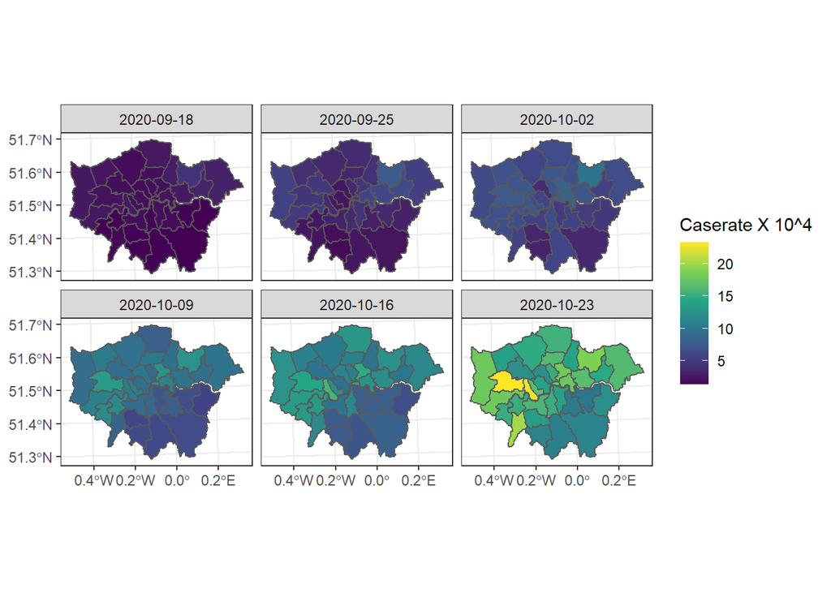

We consider a space-time Poisson regression with space-time random effects
$$y_{st} \sim Poi(\lambda_{st}),\quad
\log(\lambda_{st})= \log(o_s) + \beta_0 + \beta_1\cdot x_{st} +
\phi_{st}$$
where the offset $o_s$ is the population size divided by $10^4$ and $\phi_{st}$ is modeled according to the Leroux-AR model.

We will fit to these data the Leroux-AR version, available in the folder as *LerouxAR_Sparse.stan*. It exploits the Leroux sparse representation and adopts the non-centered parametrization. The core of the non-centered parametrization is in the following chunk of STAN code.

```r
transformed parameters {
        ...

        vector[Nobs] phi;

        phi[tdId[1]] = sigmac*phis[1];
        for (i in 2:Ntimes)  phi[tdId[i]] = rho*phi[tdId[i-1]] + sigmac*phis[i];

        ...
    }


model {
        ...

        {
          vector[N] ldet_terms;
          real sumlogdet;

          // CAR determinant
          for (i in 1:N){
            ldet_terms[i] = log1m(alpha * lambda[i]);
          }
          sumlogdet = sum(ldet_terms);

          // CAR prior
          for (i in 1:Ntimes) phis[i] ~ sparse_Leroux(alpha, W_sparse, W_weight,
                                                      ID_sparse, sumlogdet, N, W_n);

        }

      ...
    }
```

We can prepare the data for input in STAN.

```r
# Data
Y <- as.integer(londonDat$Y)
Nobs <- length(Y)
Ntimes <- as.integer(length(unique(londonDat$wdate)))
N <- as.integer(length(unique(londonDat$areaName)))
tdId <- matrix(as.integer(1:(N*Ntimes)),  ncol=N, nrow=Ntimes, byrow = T)
X <- model.matrix(~.,
                  data=londonDat %>% dplyr::select(popden) %>%
                    mutate(across(everything(), function(x) scale(log(x)))))
E <- londonDat$popn/10000

# Data for Stan
datalist <- list(Nobs = Nobs,
                 Y = Y,
                 lOff = log(E),
                 N = N,
                 tdId = tdId,
                 Ntimes=Ntimes,
                 W = W,
                 W_n = sum(W[upper.tri(W)]>0),
                 k = ncol(X),
                 X = X)
```

We can then setup the STAN options and compile the STAN code.

```r
n_iter <- 4000
n_chains <- 2
n_cores <- max(n_chains, parallel::detectCores()-1)

# Stan compilation
stan_CodeLerAR <- stan_model("LerouxAR_Sparse.stan")
```

Finally, we can fit the model and analyze the results. We set `adapt_delta=0.7` only to speed up the fitting in this `.Rmd`, but it is kindly suggested to increase it to improve the convergence.

```r
# Fitting -----------------------------------------------

fit_LerAR <- sampling(stan_CodeLerAR, data = datalist,
                      chains = n_chains, iter = n_iter,
                      cores = n_cores,
                      pars = c("lm", "phis"), include=F, seed=111,
                      control = list(adapt_delta=0.7))

# Summary and visualization -----------------------------------------------

betas <- paste0("beta[", 1:(ncol(X)), "]")
cars <- c("alpha", "sigmac")

# Check divergences
np_LerAR <- bayesplot::nuts_params(fit_LerAR)

# The summary
sumLerAR <- summary(fit_LerAR, pars=c(betas, cars))
sumLerAR$summary
```

```
##              mean      se_mean          sd          2.5%       25%        50%
## beta[1] 1.8549235 0.0001057698 0.007005316  1.8410727597 1.8502445 1.85506777
## beta[2] 0.0494196 0.0006801474 0.025327083 -0.0007022721 0.0332782 0.04979467
## alpha   0.9928781 0.0001164473 0.004031001  0.9832572901 0.9907044 0.99369335
## sigmac  0.2579203 0.0024757393 0.020271329  0.2193204395 0.2441606 0.25736067
##                75%      97.5%      n_eff     Rhat
## beta[1] 1.85962965 1.86879801 4386.63752 1.000252
## beta[2] 0.06628152 0.09803143 1386.64160 1.001844
## alpha   0.99587667 0.99833628 1198.30327 1.001715
## sigmac  0.27105377 0.29809278   67.04318 1.021772
```

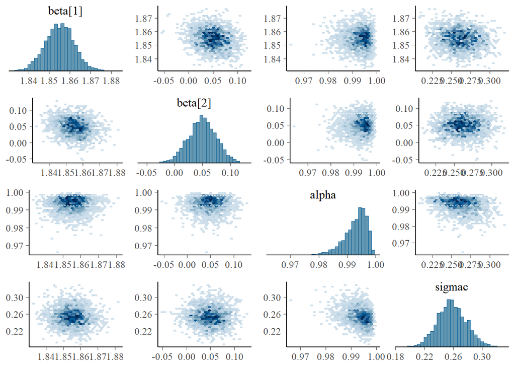

```r
# Extracting pars
pParsAR <- rstan::extract(fit_LerAR, permuted = FALSE, pars=c(betas, cars))


bayesplot::mcmc_pairs(pParsAR,
                      np=np_LerAR,
                      off_diag_fun = c("hex"))
```

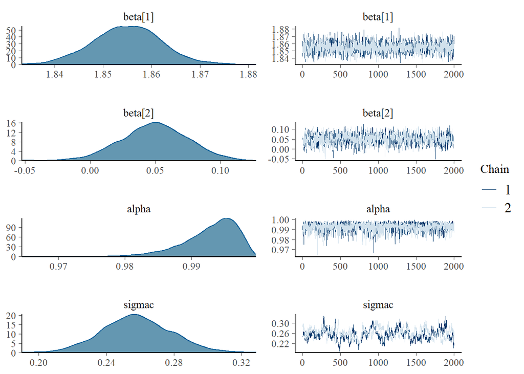

```r
bayesplot::mcmc_combo(pParsAR,
                      np=np_LerAR)
```

Carpenter, Bob, Andrew Gelman, Matthew D Hoffman, Daniel Lee, Ben Goodrich, Michael Betancourt, Marcus A Brubaker, Jiqiang Guo, Peter Li, and Allen Riddell. 2017. “Stan: A Probabilistic Programming Language.” *Grantee Submission* 76 (1): 1–32.

Jin, Xiaoping, Bradley P Carlin, and Sudipto Banerjee. 2005. “Generalized Hierarchical Multivariate CAR Models for Areal Data.” *Biometrics* 61 (4): 950–61.

Joseph, Max. 2016. “Exact Sparse CAR Models in Stan, 2016.” *URL Http://Mc-Stan. Org/Users/Documentation/Case-Studies/Mbjoseph-CARStan. Html*.

R Core Team. 2019. *R: A Language and Environment for Statistical Computing*. Vienna, Austria: R Foundation for Statistical Computing. https://www.R-project.org/.

Rushworth, Alastair, Duncan Lee, and Richard Mitchell. 2014. “A Spatio-Temporal Model for Estimating the Long-Term Effects of Air Pollution on Respiratory Hospital Admissions in Greater London.” *Spatial and Spatio-Temporal Epidemiology* 10: 29–38.